# Eurovision Song Contest country profile

2025-05-02

# Denmark

## Participation and successes

Denmark has participated in the Eurovision Song Contest 52 times. It made it to the final round 44 times - that’s 84.6%.

Denmark has won 3 times. Its most successful performance took place in the 1963 final, when the country got 17.5% of all possible points.

## Final place distribution

Here’s how many times Denmark earned a particular place in the final round of Eurovision:

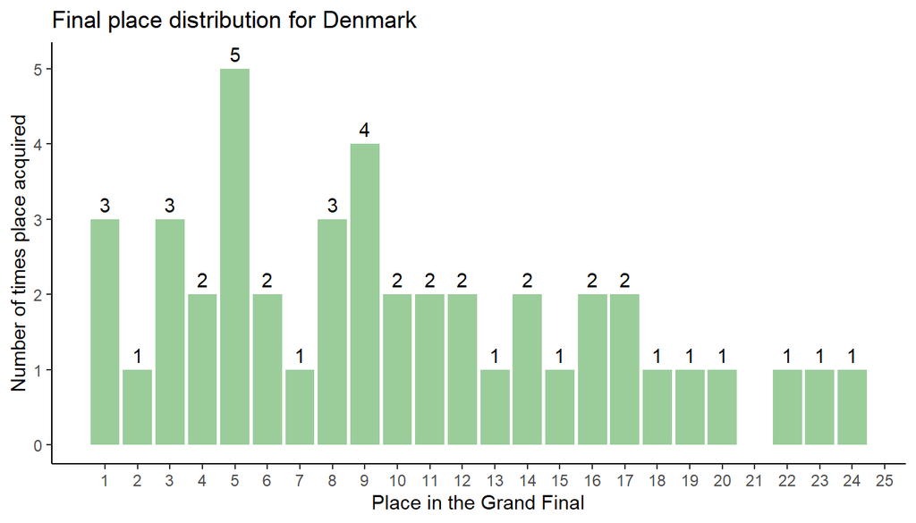

## Loyal besties

Below are the countries that have NEVER given Denmark zero points. The bar chart shows the lowest score those countries gave Denmark instead.

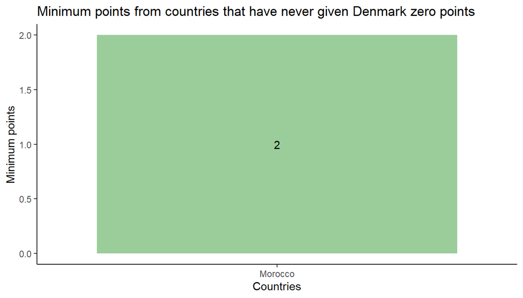

## Only zeros

On the other hand, here are the countries that have never given Denmark more than zero points.

```
## countries that have never given  Denmark  more than zero points:
##
## - Serbia and Montenegro
## - World
```

## Birds of a feather sing together

The European Broadcasting Union started separating televote (votes cast by audience) and jury vote (votes cast by official representatives of each participating country) in 2016. Below is a chart that shows top five countries whose public voted for Denmark and top five countries that Denmark public voted for the most between 2016 and 2024:

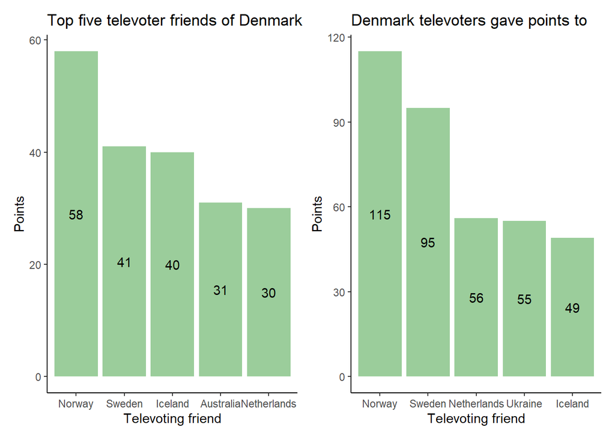

Below is a chart that shows top five countries whose jury voted for Denmark and top five countries that Denmark jury voted for the most between 2016 and 2024:

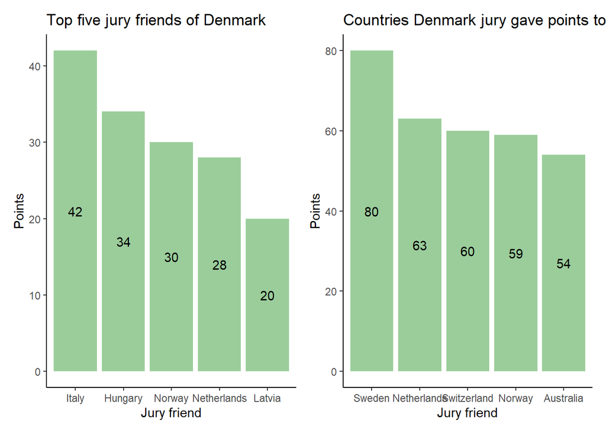

Finally, here is a chart that shows overall (televote and jury vote combined) top five countries that voted for Denmark and top five countries that Denmark voted for the most between 1957 and 2024:

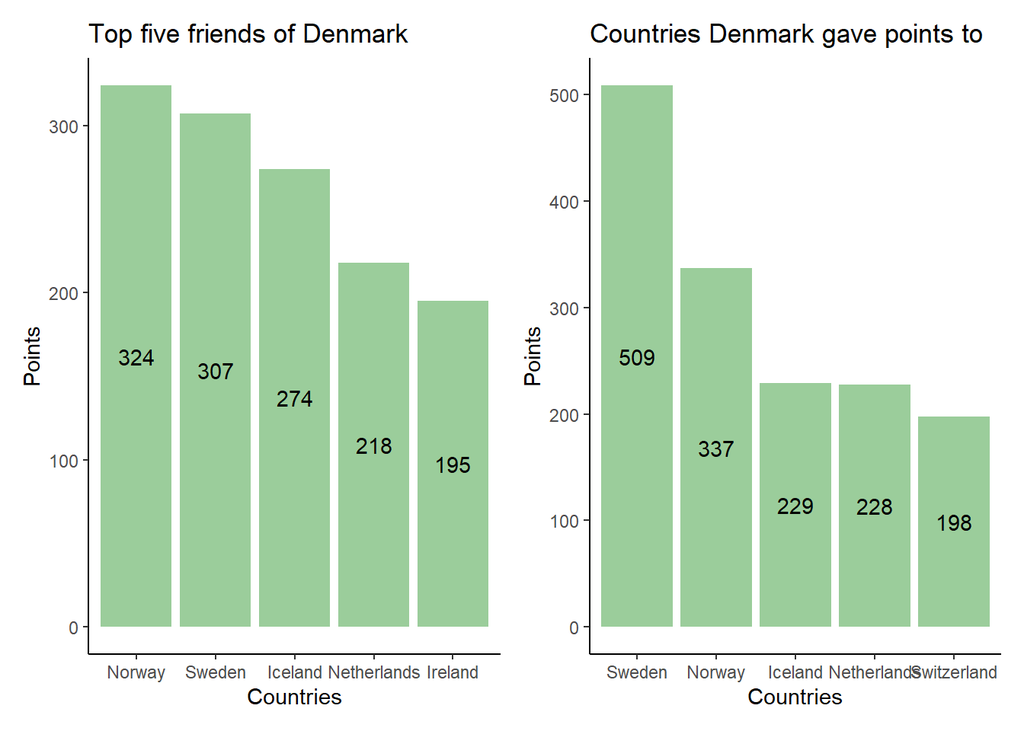